# Estadística-FinalProject

César López Mantecón y Manuel Gómez-Plana Rodriguez

2022-12-04

# Introducción

En este estudio se pretende establacer si existe alguna relación entre el tiempo de uso de los dispositivos electrónicos con fines de ocio y el tiempo dedicado a actividades extracurriculares de estudiantes universitarios y de educación secundaria. Además, se pretenderá establecer si hombres y mujeres presentan diferentes tendenciase en el tiempo de uso de estos dispositivos para su entretenimiento.

## Variables estudiadas

- Variable principal:
  - T: tiempo de uso de dispositivos con fines de ocio al día.
- Variables secundarias:
  - Sexo: 1 si es hombre, 0 si es mujer.
  - Edad: número de años de la persona
  - T.trab: tiempo dedicado a una actividad remunerada a la semana.
  - T.Ext: tiempo dedicado a una actividad extracurricular a la semana.
  - Estudios: nivel de estudios cursados en el momento. 1:= Universidad, 0:= Instituto

# Estudio descriptivo

## Resumen de T:

**Tabla de frencuencias absolutas de T:**

```r
library(readxl)
data <- read_excel("data_filtered.xlsx")
ABStable <- table(data$'T')
ABStable
```

```
##
##  1  2  3  4  5  6  7  8  9 10 11
##  3  7 16 15 12  7  5  5  1  1  2
```

**Tabla de frecuencias relativas de T:**

```r
RELtable <- prop.table(ABStable)
RELtable
```

```
##
##          1          2          3          4          5          6          7
## 0.04054054 0.09459459 0.21621622 0.20270270 0.16216216 0.09459459 0.06756757
##          8          9         10         11
## 0.06756757 0.01351351 0.01351351 0.02702703
```

Los valores más comunes son 3, 4 y 5. Tratándose de un 58% de la muestra, aproximadamente. Respectivamente, estos valores aparecen con una frecuencia absoluta de: 16, 15 y 12.

**Medidas características de T:**

```r
suppressWarnings(library(summarytools))
descr(data$T)
```

```
## Descriptive Statistics
## value
## N: 74
##
##                      value
## ----------------- --------
##              Mean     4.64
##           Std.Dev     2.24
##               Min     1.00
##                Q1     3.00
##            Median     4.00
##                Q3     6.00
##               Max    11.00
##               MAD     1.48
##               IQR     3.00
##                CV     0.48
##          Skewness     0.82
##       SE.Skewness     0.28
##          Kurtosis     0.39
##           N.Valid    74.00
##         Pct.Valid   100.00
```

**Diagrama de barras de T**

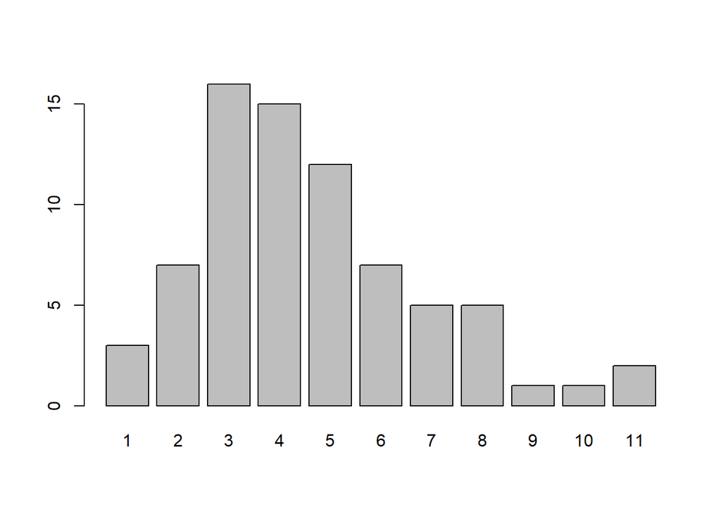

```r
barplot(ABStable)
```

La distribución muestra una asimetría positiva. Vemos que los datos más frecuentes son 3, 4 y 5, como ya habíamos confirmado antes. También vemos qque tiene forma acampanada.

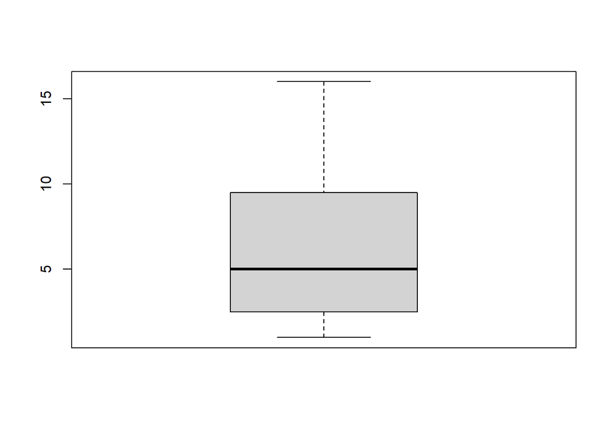

```r
boxplot(ABStable)
```

Para determinar si hay diferencias notorias por sexo, separamos la población en hombres y mujeres. No sin antes echar un vistazo a la proporción de estos: Proporción por sexo:

```r
ABStable_sexo <- table(data$Sexo)
lbls <- c("Mujeres", "Hombre")
row.names(ABStable_sexo) <- lbls
RELTable_sexo <- prop.table(table(data$`Sexo`))
row.names(RELTable_sexo) <- lbls
RELTable_sexo
```

```
##
##   Mujeres    Hombre
## 0.4324324 0.5675676
```

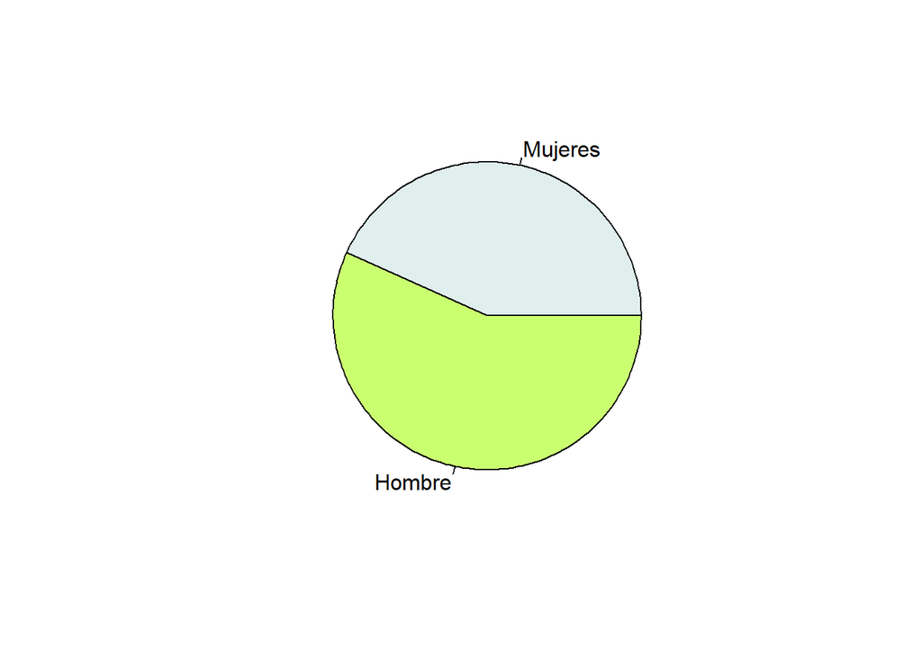

```r
pie(ABStable_sexo, col=c("azure2", "darkolivegreen1"))
```

Diagramas segregados por sexo:

```r
ABStable_mujer <- table(data$T[data$Sexo==0])
descr(data$T[data$Sexo==0])
```

```
## Descriptive Statistics
## value
## N: 32
##
##                      value
## ----------------- --------
##              Mean     5.25
##           Std.Dev     2.41
##               Min     1.00
##                Q1     4.00
##            Median     5.00
##                Q3     6.50
##               Max    11.00
##               MAD     1.48
##               IQR     2.25
##                CV     0.46
##          Skewness     0.81
##       SE.Skewness     0.41
##          Kurtosis     0.17
##           N.Valid    32.00
##         Pct.Valid   100.00
```

```r
ABStable_sexo <- table(data$T[data$Sexo==1])
descr(data$T[data$Sexo==1])
```

```
## Descriptive Statistics
## value
## N: 42
##
##                      value
## ----------------- --------
##              Mean     4.17
##           Std.Dev     2.00
##               Min     1.00
##                Q1     3.00
##            Median     4.00
##                Q3     5.00
##               Max     9.00
##               MAD     1.48
##               IQR     2.00
##                CV     0.48
##          Skewness     0.63
##       SE.Skewness     0.37
##          Kurtosis    -0.43
##           N.Valid    42.00
##         Pct.Valid   100.00
```

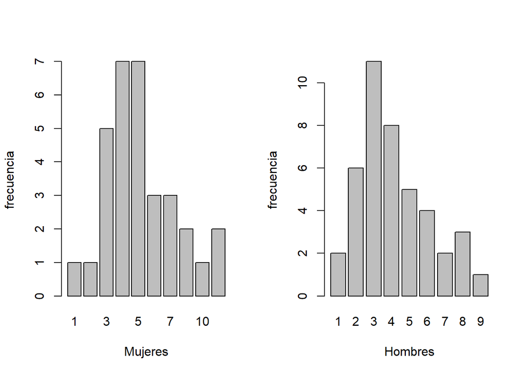

```r
par(mfrow=c(1, 2))
barplot(ABStable_mujer, xlab="Mujeres", ylab="frecuencia")
barplot(ABStable_sexo, xlab="Hombres", ylab="frecuencia")
```

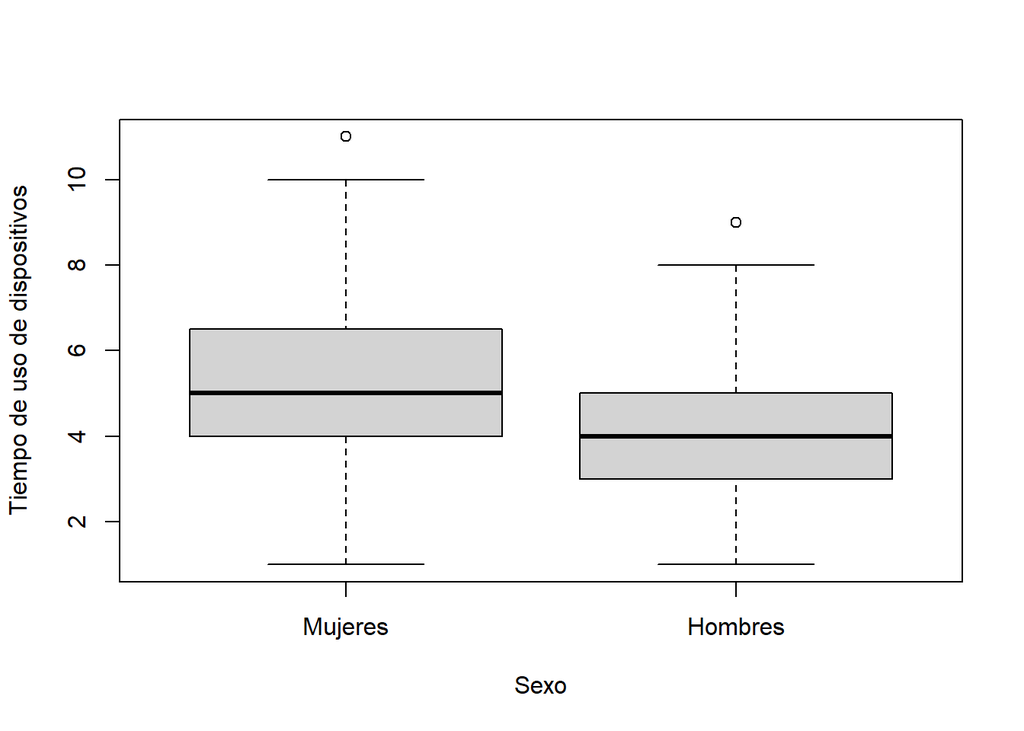

```r
boxplot(data$T ~ data$Sexo, xlab = "Sexo",
ylab = "Tiempo de uso de dispositivos", names = c("Mujeres", "Hombres"))
```

Un pequeño detalle a destacar es la presencia de un dato en ambas poblaciones.

# Ajuste de distribución

En este apartado pretendemos comprobar si nuestra distribución puede ajustarse a una distribución normal.

Ajuste a una normal:

```r
library(fitdistrplus)
normalfit <- fitdist(data$T, "norm")
normalfit
```

```
## Fitting of the distribution ' norm ' by maximum likelihood
## Parameters:
##      estimate Std. Error
## mean 4.635135  0.2582279
## sd   2.221360  0.1825945
```

Test chi-cuadrado:

```r
par(mfrow=c(1, 2))
barplot(table(data$T),  xlab = "observados")
norm = dnorm(c(1, 2, 3, 4, 5, 6, 7, 8, 9, 10, 11),normalfit$estimate[1], normalfit$estimate[2])
norm
```

```
##  [1] 0.047073958 0.088861379 0.136972218 0.172400699 0.177187328 0.148700830
##  [7] 0.101901653 0.057021175 0.026054227 0.009720919 0.002961581
```

```r
esperados = norm*74 #probabilidad por tamaño muestral
observados = table(data$T)
observados
```

```
##
##  1  2  3  4  5  6  7  8  9 10 11
##  3  7 16 15 12  7  5  5  1  1  2
```

```r
length(observados)
```

```
## [1] 11
```

```r
esperados
```

```
##  [1]  3.483473  6.575742 10.135944 12.757652 13.111862 11.003861  7.540722
##  [8]  4.219567  1.928013  0.719348  0.219157
```

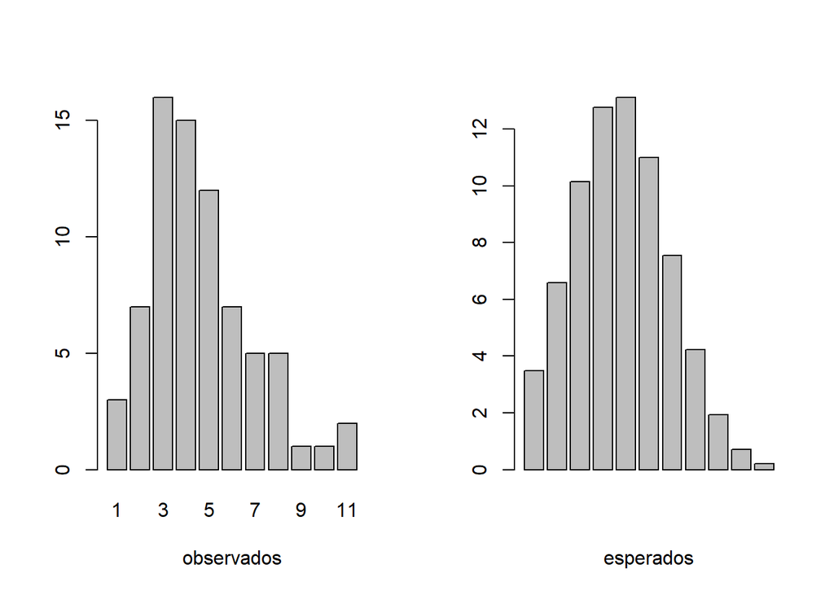

```r
barplot(esperados, xlab="esperados")
```

```r
chisq.test(observados, esperados,rescale.p = T)
```

```
##
##  Pearson's Chi-squared test
##
## data:  observados and esperados
## X-squared = 77, df = 70, p-value = 0.2647
```

```r
pchisq(77, df = 72, lower.tail = F)#reajustando df
```

```
## [1] 0.3217995
```

Al tener un p-valor > 0.05 (0.3218), concluimos que el ajuste es correcto. Nuestra distribución se ajusta a una normal:

$$T\sim N(4.63, 2.22)$$

# Intervalos de confianza

## $\mu$

Cáculo del intervalo de confianza.

```r
alpha = 0.05
xmean = mean(data$T)
xsd = sd(data$T)
t = qt(alpha/2, df=73, lower.tail = FALSE)
LowerLimit = xmean - t * xsd / sqrt(74)
UpperLimit = xmean + t * xsd / sqrt(74)
LowerLimit
```

```
## [1] 4.116975
```

```r
UpperLimit
```

```
## [1] 5.153296
```

$$\mu\in(4.1170,\ 5.1532)$$

# $\sigma^2$

```r
n = length(data$T)
s2 = var(data$T)
chi.lower = qchisq(1-alpha/2, df = n-1)
chi.upper = qchisq(alpha/2, df = n-1)
LowerLimit = (n-1) * s2 / chi.lower
UpperLimit = (n-1) * s2 / chi.upper
LowerLimit
```

```
## [1] 3.706481
```

```r
UpperLimit
```

```
## [1] 7.122793
```

H0: $\mu_{1} = \mu_2$

H1: $\mu_{1} > \mu_2$

Podemos usar el z.test ya que nuestra población tiene $n>30$

```r
library(BSDA)
z.test(data$T[data$Sexo==0], data$T[data$Sexo==1], alternative="greater", sigma.x = sd(data$T[data$Sexo==0]), sigma.y=sd(data$T[data$Sexo==1]))
```

```
##
##  Two-sample z-Test
##
## data:  data$T[data$Sexo == 0] and data$T[data$Sexo == 1]
## z = 2.0599, p-value = 0.01971
## alternative hypothesis: true difference in means is greater than 0
## 95 percent confidence interval:
##  0.2182702        NA
## sample estimates:
## mean of x mean of y
##  5.250000  4.166667
```

Dado que el p-valor es menor que 0.05, rechazamos la hipótesis nula. Podemos afirmar, que las mujeres usan más tiempo de media los dispositivos electronicos con fines de ocio.

[output not shown]

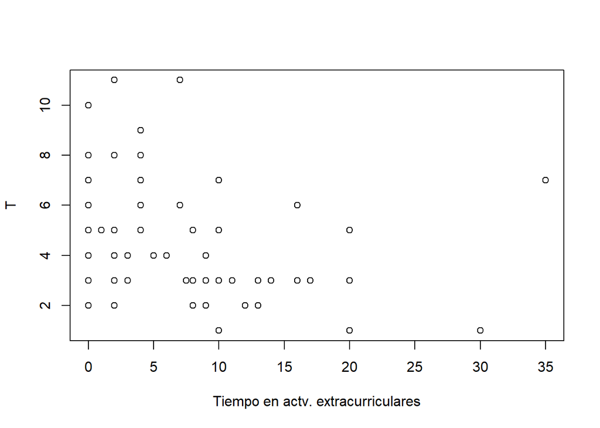

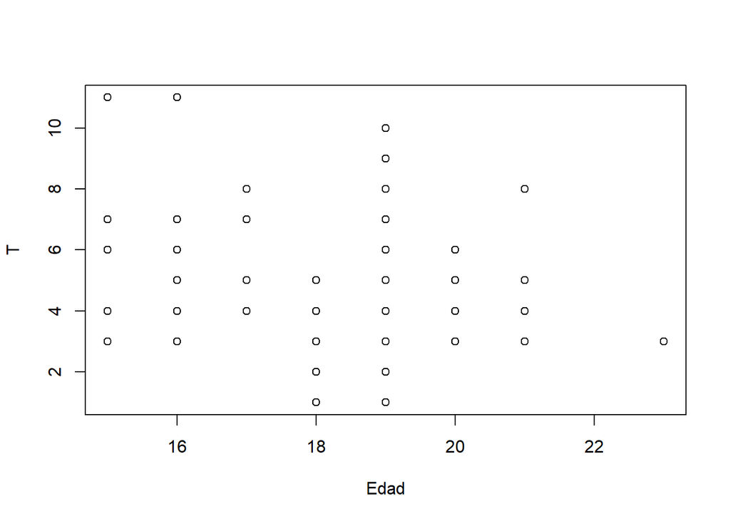

```r
plot(data$Edad, T, xlab="Edad", ylab="T")
```

Al comparar tanto con la edad como con tiempo dedicado a actividades extracurriculares, vemos que la distribución se asemeja poco a una línea. Esto puede deberse al escaso rango de edades que posee nuestra muestra. Calculando correlaciones:

Correlacíon Eda~T:

```r
cor(data$Edad, T)
```

```
## [1] -0.193281
```

COrrelación Ext~T:

```r
cor(T, Ext)
```

```
## [1] -0.289247
```

De ambas podemos concluir que el uso de dispositivos con fines lúdicos decrece con los años, pero es un coeficiente tan bajo que no podemos afirmar que la haya una variación lineal en ninguno de los casos.Aplicándolo al caso más favorable, horas dedicadas a una actividad extracurricular~T:

```r
RegressionModel <- lm(Ext~T, data=data)
print(RegressionModel)
```

```
##
## Call:
## lm(formula = Ext ~ T, data = data)
##
## Coefficients:
## (Intercept)            T
##     10.6884      -0.9226
```

```r
summary(RegressionModel)
```

```
##
## Call:
## lm(formula = Ext ~ T, data = data)
##
## Residuals:
##    Min     1Q Median     3Q    Max
## -8.843 -4.979 -1.153  2.079 30.770
##
## Coefficients:
##             Estimate Std. Error t value Pr(>|t|)
## (Intercept)  10.6884     1.8495   5.779 1.78e-07 ***
## T            -0.9226     0.3598  -2.564   0.0124 *
## ---
## Signif. codes:  0 '***' 0.001 '**' 0.01 '*' 0.05 '.' 0.1 ' ' 1
##
## Residual standard error: 6.876 on 72 degrees of freedom
## Multiple R-squared:  0.08366,    Adjusted R-squared:  0.07094
## F-statistic: 6.574 on 1 and 72 DF,  p-value: 0.01244
```

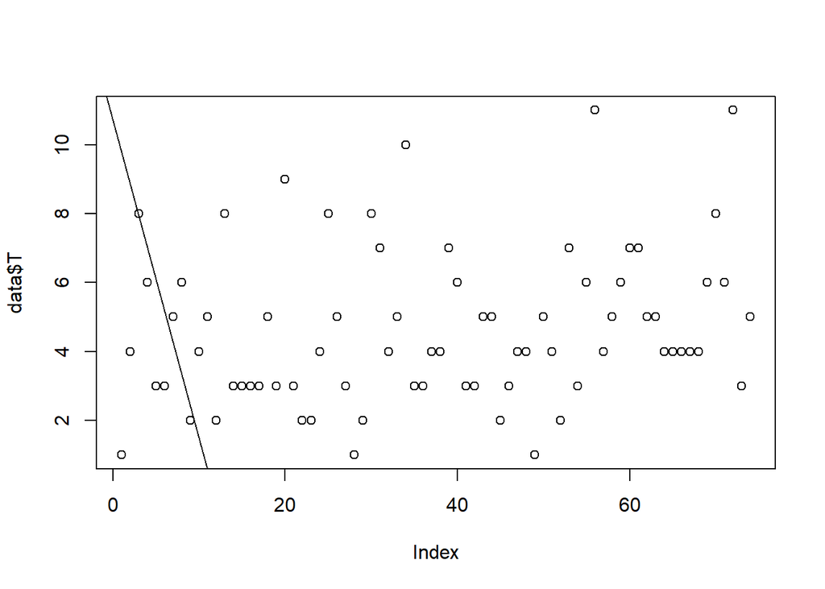

```r
plot(data$T)
abline(RegressionModel)
```

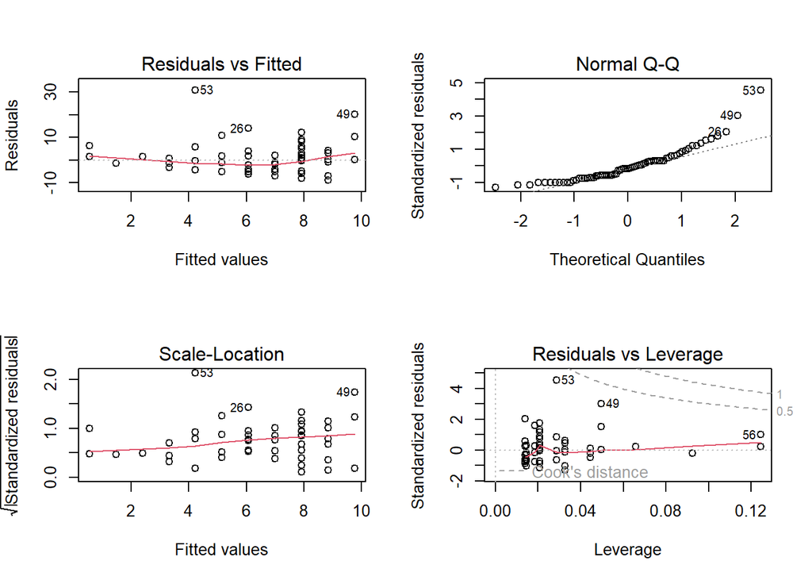

```r
par(mfrow=c(2,2))
plot(RegressionModel)
```